# Instructions for use of option pricer

Gabriel Simmonds

This option pricer has been created as part of the requirements of the Developing Data Products course in the Data Science specialization offered on Coursera.

As such, this pricer should not be used for any financial transactions. It has been created solely for demonstration purposes. No guarantees are offered as to the validity of option prices derived fom this pricer.

This pricer will attempt to use the Black-Scholes formula to price over-the-counter (OTC) options with European exercise style. The options included in this pricer are for a choice from 6 different stocks: Boeing (BA), Ford Motor (F), Tiffany (TIF), United Airlines (UAL), Uranium Energy (UEC) and 3M (MMM).

#### Step 1

The first choice to make when confronted by the display is to choose the company via a drop-down menu. Clicking on the menu will bring up the list of 6 companies, and a single choice of company can be made, appropriate to the option you wish to price.

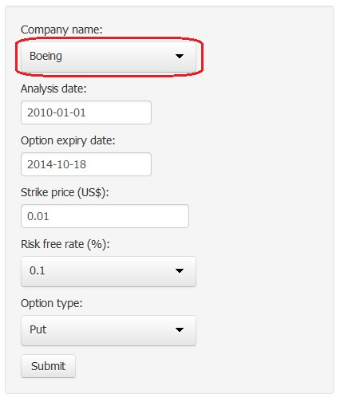

#### Step 2

The pricing analysis date should be chosen next. Any date between 1st Jan 2010 and yesterday can be chosen.

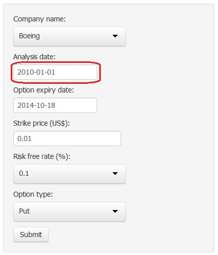

#### Step 3

Next, the option expiry date needs to be supplied. Any date after the pricing analysis date can be chosen. N.B. If you attempt to choose a date before or on the pricing analysis date, the system automatically corrects this to make the expiry date equal to the analysis date plus one day.

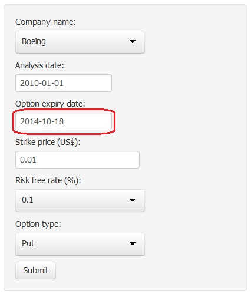

#### Step 4

The option strike price must be supplied during this next stage. Any price greater than or equal to US$ 0.01 can be chosen.

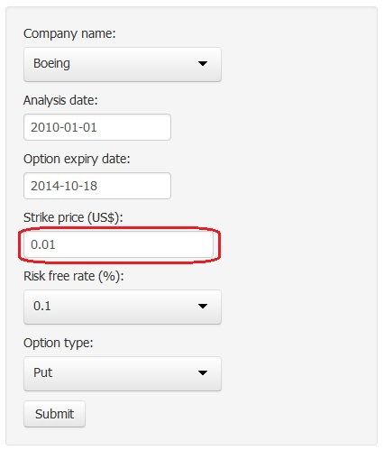

#### Step 5

Next, the risk free interest rate should be chosen. Values from 0% to 5% are available in a drop-down menu, with intervals of 0.1%.

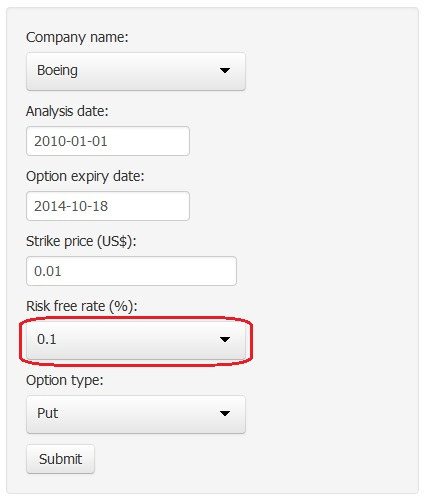

#### Step 6

The option type should be chosen now. Whether the option is a Put or a Call can be chosen via a drop-down menu.

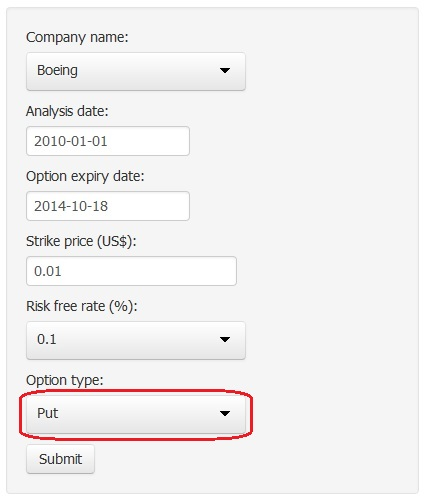

As these choices are made, you will see the relevant values displayed in the output

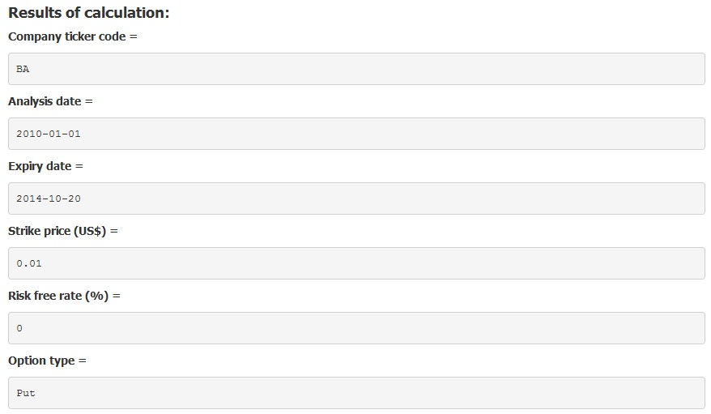

You will also see a plot of the time-series of the relevant company’s stock prices from 2009 to the latest price before today (whenever that was). This plot can be used to give an indication of strike prices which could be available at different analysis dates.

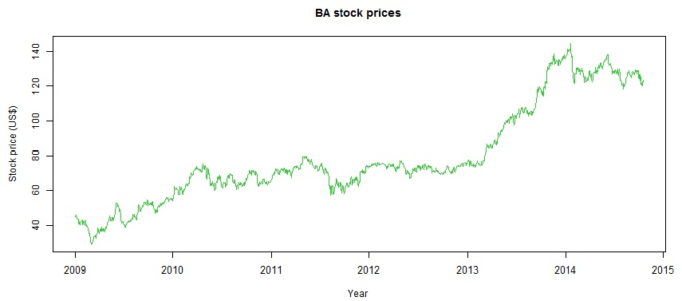

#### Step 7

Finally, press the ‘Submit’ button, and the option price will be displayed in the output

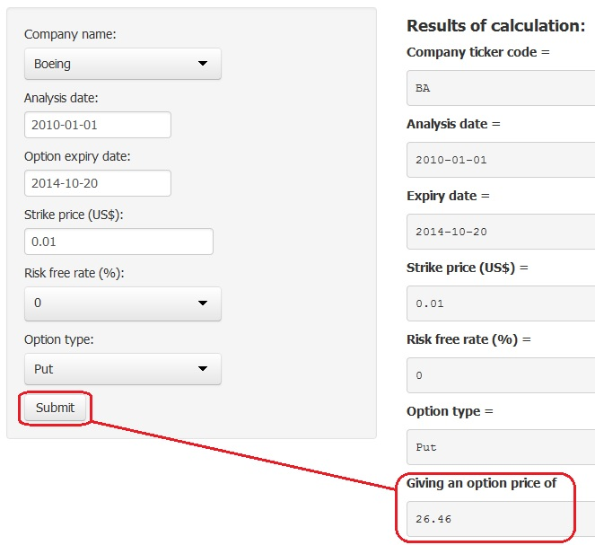

#### Trial run

As a trial, submit these choices and see if the answers you obtain match these

Company = Tiffany (TIF)  
Analysis date = 2013-10-14  
Expiry date = 2014-10-14  
Strike price = 81.5  
Risk free = 3.5%  
Option type = Call  
> Price = 0.01033

Option type = Put  
> Price = 2.247172